# Practical Machine Learning

**Step 5 - Create a Random Forest Model with the latest training data set**

```r
rf = train(classe ~., data = training7, method = "rf", ntree = 100)

rf_prediction = predict(rf, testing5)
rf_pred_conf = confusionMatrix(rf_prediction, testing5$classe)
rf_pred_conf
```

```
## Confusion Matrix and Statistics
##
##           Reference
## Prediction    A    B    C    D    E
##          A 4976  206   11   21    6
##          B   91 3136  163   18   29
##          C   25  169 2980  253   84
##          D   81   14   22 2669   34
##          E   16    6    6   29 3201
##
## Overall Statistics
##
##                Accuracy : 0.9296
##                  95% CI : (0.9258, 0.9333)
##     No Information Rate : 0.2844
##     P-Value [Acc > NIR] : < 2.2e-16
##
##                   Kappa : 0.911
##
##  Mcnemar's Test P-Value : < 2.2e-16
##
## Statistics by Class:
##
##                      Class: A Class: B Class: C Class: D Class: E
## Sensitivity            0.9590   0.8881   0.9365   0.8926   0.9544
## Specificity            0.9813   0.9795   0.9648   0.9901   0.9962
## Pos Pred Value         0.9533   0.9124   0.8488   0.9465   0.9825
## Neg Pred Value         0.9836   0.9733   0.9863   0.9792   0.9898
## Prevalence             0.2844   0.1935   0.1744   0.1639   0.1838
## Detection Rate         0.2727   0.1719   0.1633   0.1463   0.1754
## Detection Prevalence   0.2861   0.1884   0.1924   0.1546   0.1786
## Balanced Accuracy      0.9701   0.9338   0.9506   0.9414   0.9753
```

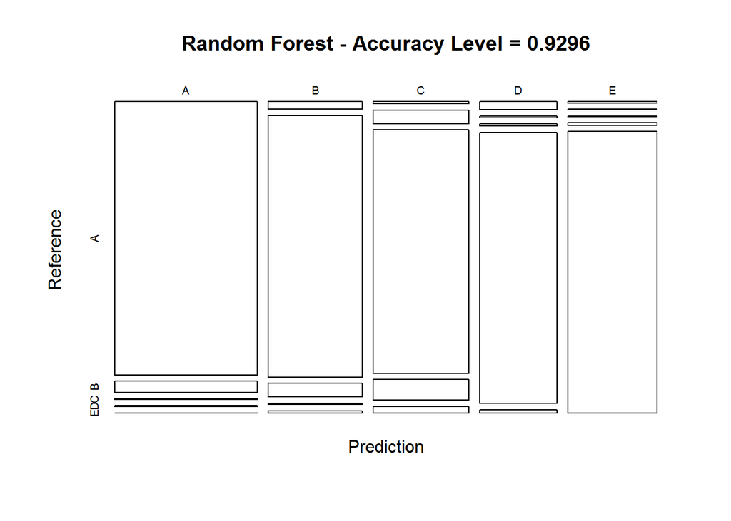

```r
plot(rf_pred_conf$table, col=rf_pred_conf$byClass,
     main=paste("Random Forest - Accuracy Level =",
                round(rf_pred_conf$overall['Accuracy'],4)))
```

**Step 6 - Create a Gradient Boosting Model to try and improve on the RF accruacy rate**

```r
gbm = train(classe ~., data = training7, method = "gbm", verbose = FALSE)
gbm$finalModel
```

```
## A gradient boosted model with multinomial loss function.
## 150 iterations were performed.
## There were 51 predictors of which 51 had non-zero influence.
```

```r
gbm_prediction = predict(gbm, testing5)
gbm_pred_conf = confusionMatrix(gbm_prediction, testing5$classe)
gbm_pred_conf
```

```
## Confusion Matrix and Statistics
##
##           Reference
## Prediction    A    B    C    D    E
##          A 5026  230   31   27   43
##          B   61 3055  187    7  174
##          C   23  176 2901  200  101
##          D   62   10   55 2621   65
##          E   17   60    8  135 2971
##
## Overall Statistics
##
##                Accuracy : 0.9084
##                  95% CI : (0.9041, 0.9125)
##     No Information Rate : 0.2844
##     P-Value [Acc > NIR] : < 2.2e-16
##
##                   Kappa : 0.884
##
##  Mcnemar's Test P-Value : < 2.2e-16
##
## Statistics by Class:
##
##                      Class: A Class: B Class: C Class: D Class: E
## Sensitivity            0.9686   0.8652   0.9117   0.8766   0.8858
## Specificity            0.9746   0.9708   0.9668   0.9874   0.9852
## Pos Pred Value         0.9382   0.8769   0.8530   0.9317   0.9311
## Neg Pred Value         0.9874   0.9678   0.9811   0.9761   0.9746
## Prevalence             0.2844   0.1935   0.1744   0.1639   0.1838
## Detection Rate         0.2755   0.1674   0.1590   0.1436   0.1628
## Detection Prevalence   0.2936   0.1909   0.1864   0.1542   0.1749
## Balanced Accuracy      0.9716   0.9180   0.9392   0.9320   0.9355
```

**The Gradient Boosting Model has a prediction rate of 91% - A slight decrease vs. the RF accuracy rate**

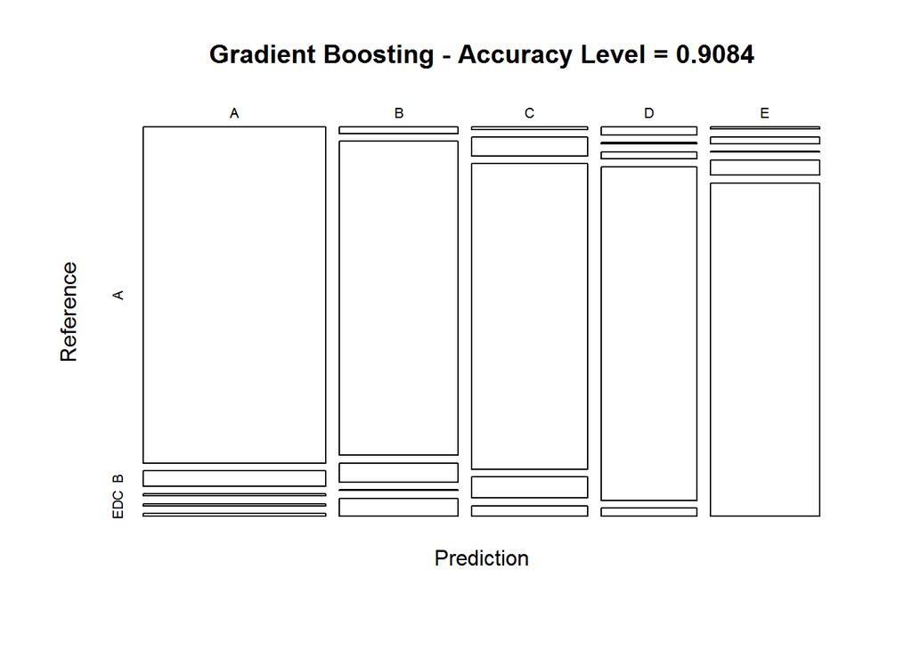

```r
plot(gbm_pred_conf$table, col=gbm_pred_conf$byClass,
     main=paste("Gradient Boosting - Accuracy Level =",
                round(gbm_pred_conf$overall['Accuracy'],4)))
```

**Step 7 - Testing the Validation data for the RF & GB models since the accuracy for the DT wasn’t satisfactory**

```r
rf_pred_conf$overall
```

```
##       Accuracy          Kappa  AccuracyLower  AccuracyUpper   AccuracyNull
##   9.296284e-01   9.109758e-01   9.258208e-01   9.332984e-01   2.843911e-01
## AccuracyPValue  McnemarPValue
##   0.000000e+00   7.400444e-73
```

```r
gbm_pred_conf$overall
```

```
##       Accuracy          Kappa  AccuracyLower  AccuracyUpper   AccuracyNull
##   9.083635e-01   8.839504e-01   9.040844e-01   9.125118e-01   2.843911e-01
## AccuracyPValue  McnemarPValue
##   0.000000e+00   9.486741e-73
```

**Step 8 - Conclusion & Final Prediction** *The Random Forest will be selected as the Final Model due to overall accuracy*

```r
final_rf = predict(rf, testing2)
final_rf
```

```
##  [1] B A A A A E D B A A B C B A E E A B B B
## Levels: A B C D E
```